# R Notebook

# Packages

```r
library(tidyverse)
```

```r
library(plotrix)
library(car)
```

# Biomass Measurements

```r
biomass <- read.csv("~/Documents/LabStats/Clusia/GrowthMeasurements.csv", header = TRUE, stringsAsFactors = TRUE, na.strings = "NA")
biomass <- biomass %>%
  arrange(Condition, Treatment, SampleNumber)
```

## Controls

```r
controls <- biomass %>%
  filter(Treatment == "Control" | Treatment == "Control Mock")

# pot weight
potwt.control <- aov(PotWt ~ Condition * Treatment, data = controls)
summary(potwt.control) # no difference between control and control mock
```

```
##                     Df Sum Sq Mean Sq F value  Pr(>F)
## Condition            1  7.565   7.565  11.479 0.00375 **
## Treatment            1  0.005   0.005   0.007 0.93517
## Condition:Treatment  1  0.085   0.085   0.128 0.72496
## Residuals           16 10.544   0.659
## ---
## Signif. codes:  0 '***' 0.001 '**' 0.01 '*' 0.05 '.' 0.1 ' ' 1
```

```r
# leaf fresh weight
leaf_fw.control <- aov(Leaf_FreshWt ~ Condition * Treatment, data = controls)
summary(leaf_fw.control)  # no difference between control and control mock
```

```
##                     Df Sum Sq Mean Sq F value   Pr(>F)
## Condition            1  14626   14626  46.102 4.34e-06 ***
## Treatment            1    460     460   1.451    0.246
## Condition:Treatment  1    496     496   1.564    0.229
## Residuals           16   5076     317
## ---
## Signif. codes:  0 '***' 0.001 '**' 0.01 '*' 0.05 '.' 0.1 ' ' 1
```

```r
# soil water
soilwater.control <- aov(SoilWater ~ Condition * Treatment, data = controls)
summary(soilwater.control) # no difference between control and control mock
```

```
##                     Df Sum Sq Mean Sq F value   Pr(>F)
## Condition            1  15410   15410  52.400 1.98e-06 ***
## Treatment            1     63      63   0.214    0.650
## Condition:Treatment  1    156     156   0.531    0.477
## Residuals           16   4705     294
## ---
## Signif. codes:  0 '***' 0.001 '**' 0.01 '*' 0.05 '.' 0.1 ' ' 1
```

```r
# total dry weight
totaldrywt.control <- aov(Total_DryWt ~ Condition * Treatment, data = controls)
summary(totaldrywt.control) # no difference between control and control mock
```

```
##                     Df Sum Sq Mean Sq F value  Pr(>F)
## Condition            1   3061  3060.8   9.789 0.00648 **
## Treatment            1      2     1.5   0.005 0.94548
## Condition:Treatment  1     70    70.4   0.225 0.64152
## Residuals           16   5003   312.7
## ---
## Signif. codes:  0 '***' 0.001 '**' 0.01 '*' 0.05 '.' 0.1 ' ' 1
```

```r
# root biomass
rootbiomass.control <- aov(RootBiomass ~ Condition * Treatment, data = controls)
summary(rootbiomass.control) # no difference between control and control mock
```

```
##                     Df Sum Sq Mean Sq F value  Pr(>F)
## Condition            1 1860.3  1860.3   9.699 0.00668 **
## Treatment            1   60.7    60.7   0.316 0.58159
## Condition:Treatment  1   31.9    31.9   0.166 0.68876
## Residuals           16 3068.8   191.8
## ---
## Signif. codes:  0 '***' 0.001 '**' 0.01 '*' 0.05 '.' 0.1 ' ' 1
```

```r
# root:shoot
rootshoot.control <- aov(RootShoot ~ Condition * Treatment, data = controls)
summary(rootshoot.control) # slight interaction term, but negligible
```

```
##                     Df Sum Sq Mean Sq F value Pr(>F)
## Condition            1  4.381   4.381   3.181 0.0935 .
## Treatment            1  3.621   3.621   2.629 0.1244
## Condition:Treatment  1  8.276   8.276   6.010 0.0261 *
## Residuals           16 22.031   1.377
## ---
## Signif. codes:  0 '***' 0.001 '**' 0.01 '*' 0.05 '.' 0.1 ' ' 1
```

```r
# RMF
rmf.control <- aov(RMF ~ Condition * Treatment, data = controls)
summary(rmf.control)
```

```
##                     Df  Sum Sq Mean Sq F value Pr(>F)
## Condition            1 0.00920 0.00920   1.636 0.2191
## Treatment            1 0.00588 0.00588   1.045 0.3220
## Condition:Treatment  1 0.03466 0.03466   6.161 0.0245 *
## Residuals           16 0.09000 0.00563
## ---
## Signif. codes:  0 '***' 0.001 '**' 0.01 '*' 0.05 '.' 0.1 ' ' 1
```

```r
# removing control mock
biomass <- biomass %>%
  filter(Treatment != "Control Mock")
```

## Summary Stats

```r
biomass.sum <- biomass %>%
  group_by(Condition) %>%
  summarise_at(c("PotWt", "Leaf_FreshWt", "SoilWater", "Total_DryWt", "RootBiomass", "RootShoot", "RMF"), funs(mean, sd, std.error))
View(biomass.sum)

biomass.sum2 <- biomass %>%
  group_by(Condition, Treatment) %>%
  summarise_at(c("PotWt", "Leaf_FreshWt", "SoilWater", "Total_DryWt", "RootBiomass", "RootShoot", "RMF"), funs(mean, sd, std.error))
View(biomass.sum2)
```

## ANOVAs

```r
mytheme <- theme_bw() + theme(
  panel.grid.major = element_blank(),
  panel.grid = element_blank(),
  axis.text.x = element_text(angle = 30, hjust = 1, vjust = 1)
)
```

### Leaf Fresh Weight

```r
leaf.aov <- aov(Leaf_FreshWt ~ Condition*Treatment, data = biomass)
summary(leaf.aov)
```

```
##                     Df Sum Sq Mean Sq F value   Pr(>F)
## Condition            1  83309   83309  21.858 1.71e-05 ***
## Treatment            4  20970    5242   1.375    0.253
## Condition:Treatment  4  19164    4791   1.257    0.297
## Residuals           60 228680    3811
## ---
## Signif. codes:  0 '***' 0.001 '**' 0.01 '*' 0.05 '.' 0.1 ' ' 1
```

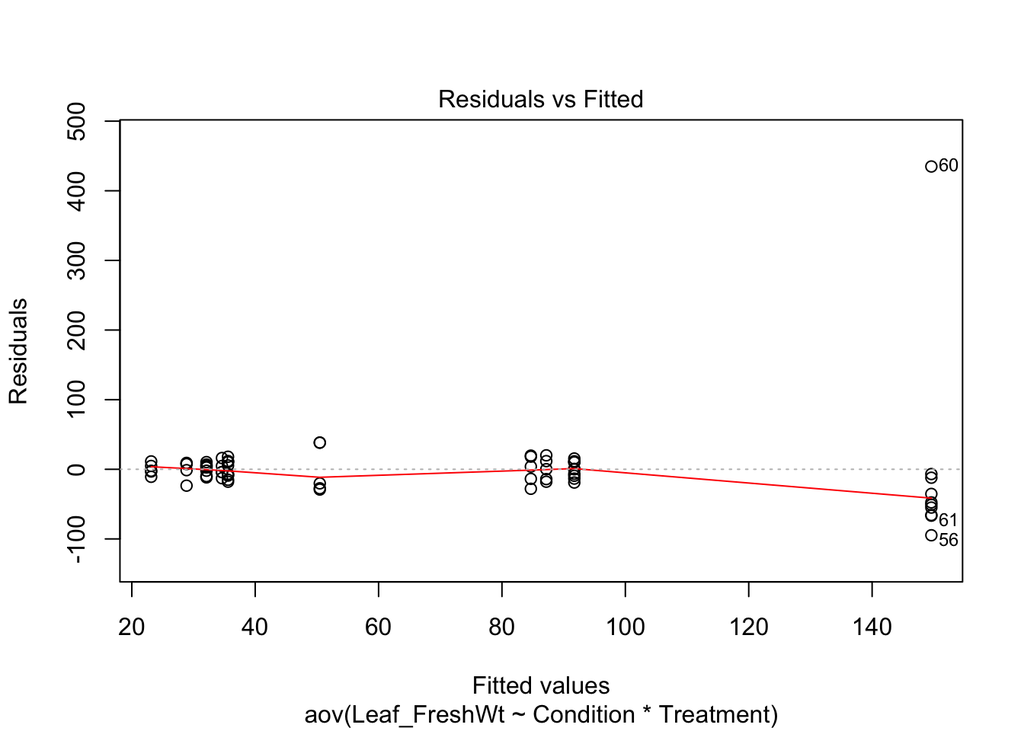

```r
# testing variance
plot(leaf.aov, 1)
```

```r
leveneTest(Leaf_FreshWt ~ Condition*Treatment, data = biomass)
```

|  | Df | F value | Pr(>F) |
| --- | --- | --- | --- |
| group | 9 | 0.9348054 | 0.5021551 |
|  | 60 | NA | NA |

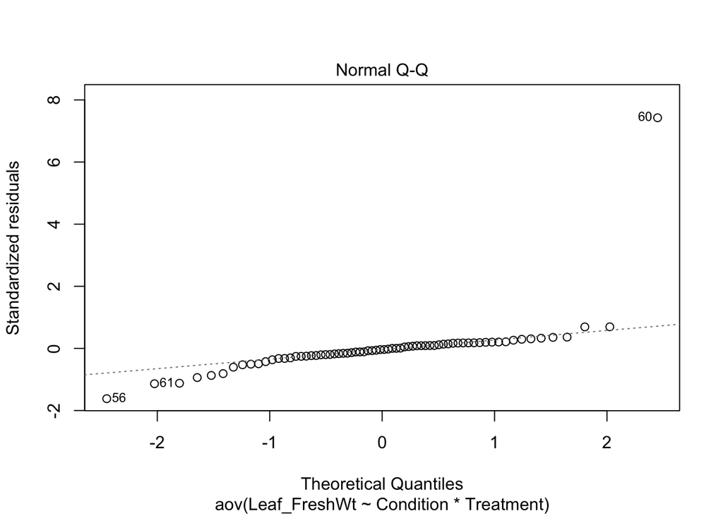

```r
# testing normality
plot(leaf.aov, 2)
```

```r
leaf.residuals <- residuals(object = leaf.aov)
shapiro.test(x = leaf.residuals)
```

```
##
##  Shapiro-Wilk normality test
##
## data:  leaf.residuals
## W = 0.42279, p-value = 4.11e-15
```

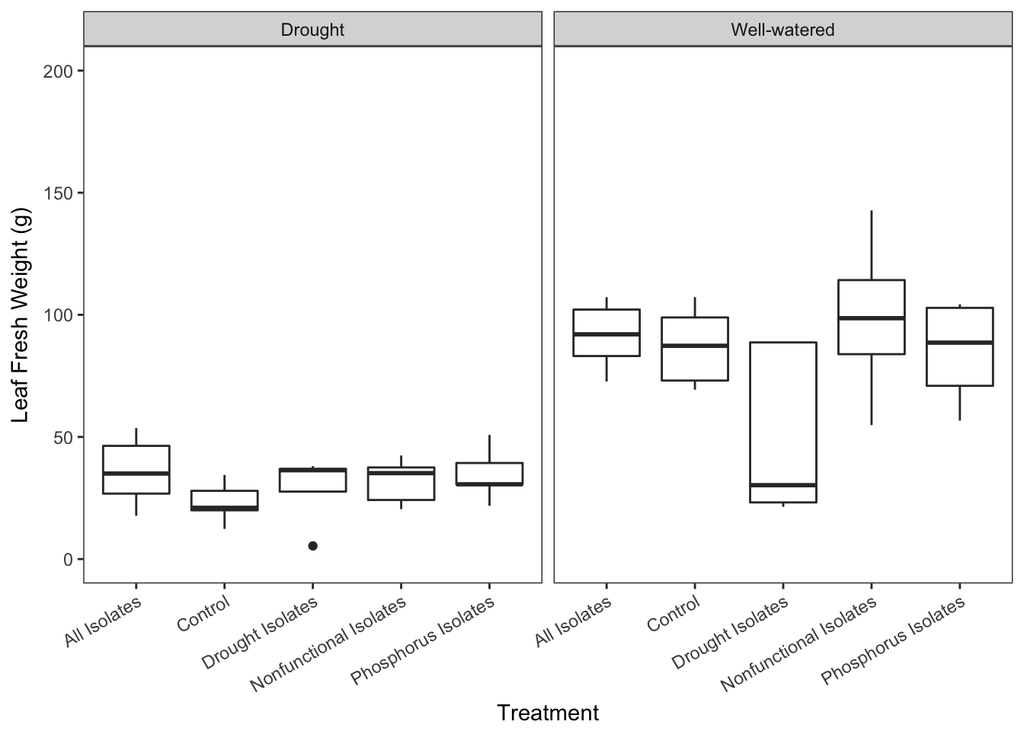

```r
ggplot(data = biomass, aes(x = Treatment, y = Leaf_FreshWt)) + geom_boxplot() + facet_grid(. ~ Condition) + scale_y_continuous(limits = c(0, 200)) + mytheme + ylab("Leaf Fresh Weight (g)")
```

### Soil Water

```r
soilwater.aov <- aov(SoilWater ~ Condition*Treatment, data = biomass)
summary(soilwater.aov)
```

```
##                     Df Sum Sq Mean Sq F value Pr(>F)
## Condition            1  55623   55623 222.891 <2e-16 ***
## Treatment            4   1150     287   1.152  0.341
## Condition:Treatment  4   1570     393   1.573  0.193
## Residuals           60  14973     250
## ---
## Signif. codes:  0 '***' 0.001 '**' 0.01 '*' 0.05 '.' 0.1 ' ' 1
```

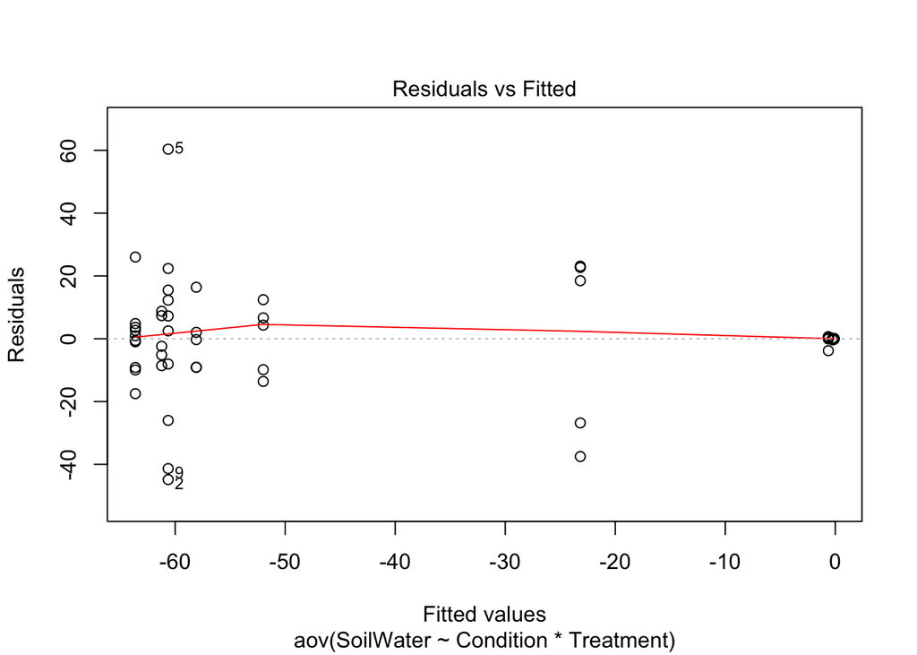

```r
# homogeneity of variance
plot(soilwater.aov, 1)
```

```r
leveneTest(SoilWater ~ Condition*Treatment, data = biomass)
```

|  | Df | F value | Pr(>F) |
| --- | --- | --- | --- |
| group | 9 | 4.538753 | 0.0001407235 |
|  | 60 | NA | NA |

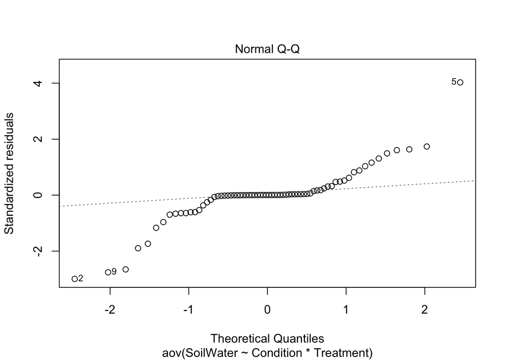

```r
# testing normality
plot(soilwater.aov, 2)
```

```r
water.residuals <- residuals(object = soilwater.aov)
shapiro.test(x = water.residuals)
```

```
##
##  Shapiro-Wilk normality test
##
## data:  water.residuals
## W = 0.83065, p-value = 1.721e-07
```

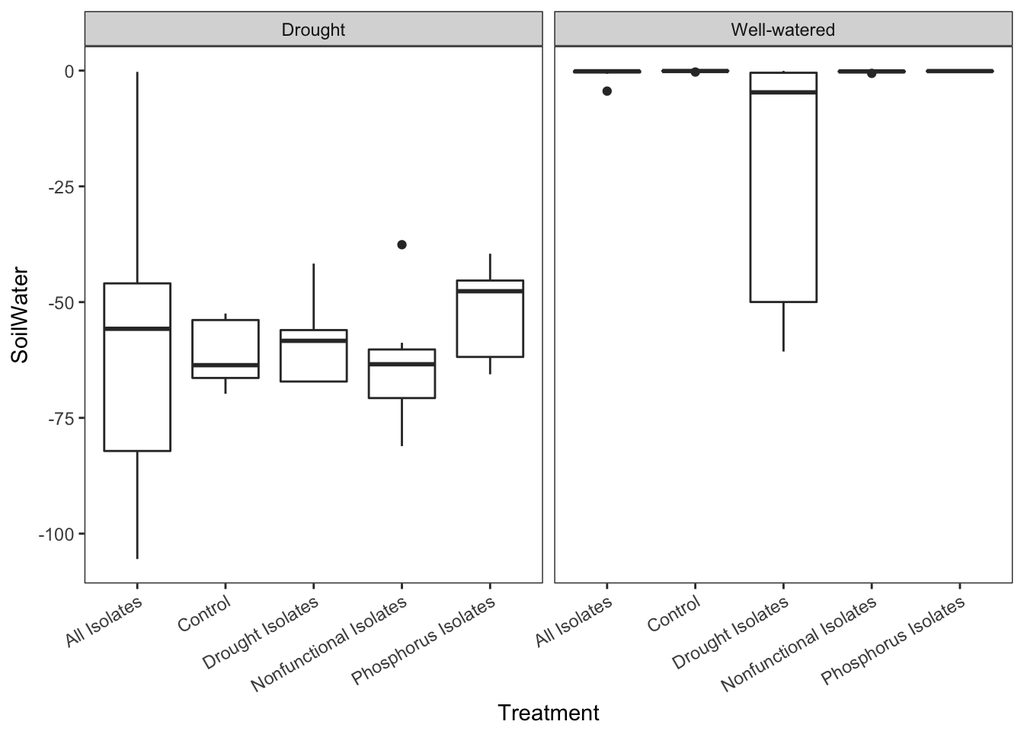

```r
ggplot(data = biomass, aes(x = Treatment, y = SoilWater)) + geom_boxplot() + facet_grid(. ~ Condition) + mytheme
```

### Total Dry Weight

```r
totaldrywt.aov <- aov(Total_DryWt ~ Condition*Treatment, data = biomass)
summary(totaldrywt.aov)
```

```
##                     Df Sum Sq Mean Sq F value   Pr(>F)
## Condition            1  18863   18863  32.100 4.41e-07 ***
## Treatment            4   1734     433   0.738    0.570
## Condition:Treatment  4   1757     439   0.747    0.564
## Residuals           60  35258     588
## ---
## Signif. codes:  0 '***' 0.001 '**' 0.01 '*' 0.05 '.' 0.1 ' ' 1
```

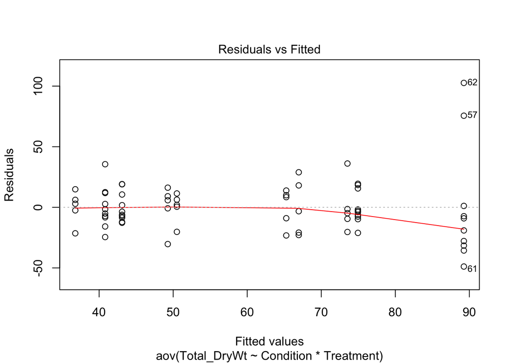

```r
# homogeneity of variance
plot(totaldrywt.aov, 1)
```

```r
leveneTest(Total_DryWt ~ Condition*Treatment, data = biomass)
```

|  | Df | F value | Pr(>F) |
| --- | --- | --- | --- |
| group | 9 | 1.454982 | 0.1858381 |
|  | 60 | NA | NA |

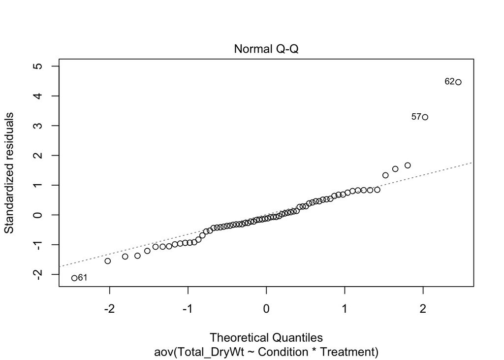

```r
# testing normality
plot(totaldrywt.aov, 2)
```

```r
totaldrywt.residuals <- residuals(object = totaldrywt.aov)
shapiro.test(x = totaldrywt.residuals)
```

```
##
##  Shapiro-Wilk normality test
##
## data:  totaldrywt.residuals
## W = 0.87475, p-value = 4.465e-06
```

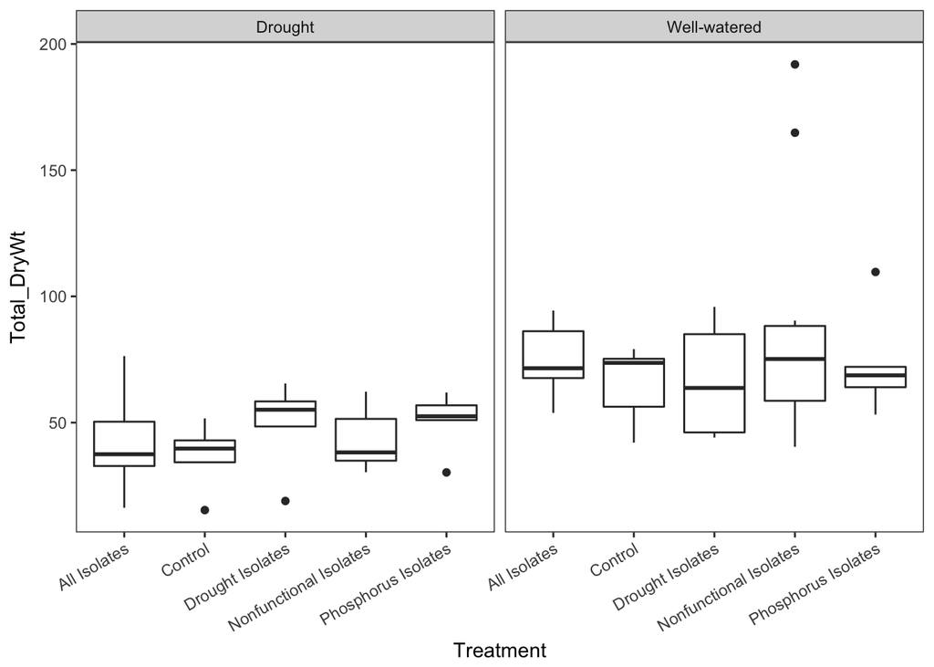

```r
ggplot(data = biomass, aes(x = Treatment, y = Total_DryWt)) + geom_boxplot() + facet_grid(. ~ Condition) + mytheme
```

### Root Biomass

```r
rootbiomass.aov <- aov(RootBiomass ~ Condition*Treatment, data = biomass)
summary(rootbiomass.aov)
```

```
##                     Df Sum Sq Mean Sq F value   Pr(>F)
## Condition            1   9392    9392  25.030 5.23e-06 ***
## Treatment            4   1191     298   0.793    0.534
## Condition:Treatment  4    587     147   0.391    0.814
## Residuals           60  22513     375
## ---
## Signif. codes:  0 '***' 0.001 '**' 0.01 '*' 0.05 '.' 0.1 ' ' 1
```

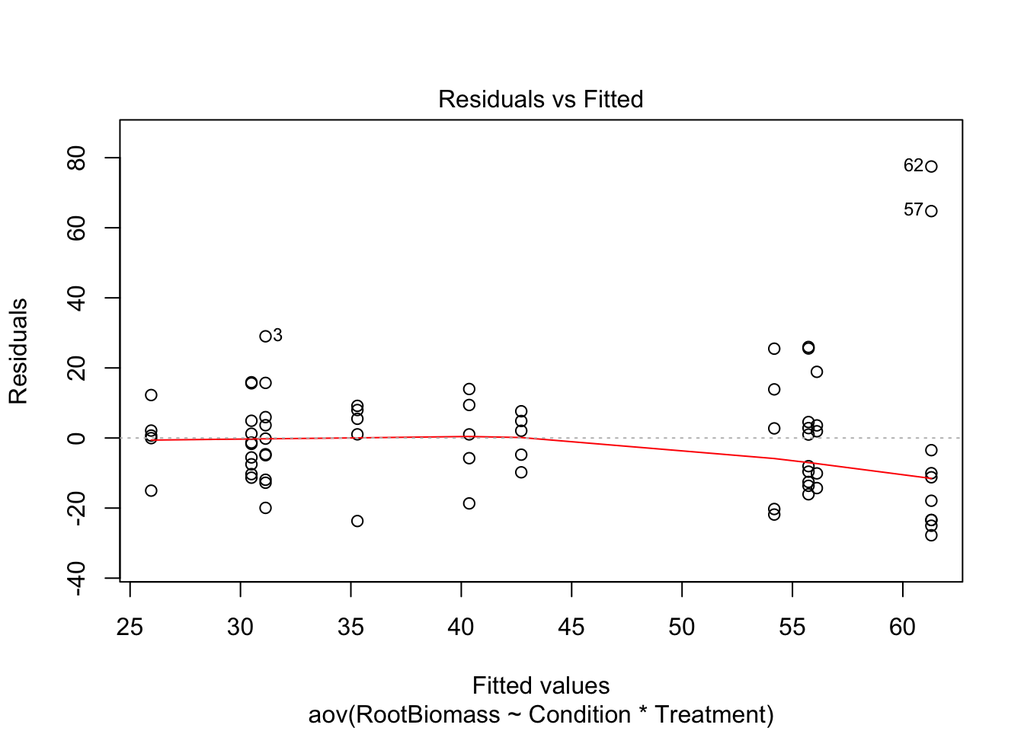

```r
# homogeneity of variance
plot(rootbiomass.aov, 1)
```

```r
leveneTest(RootBiomass ~ Condition*Treatment, data = biomass)
```

|  | Df | F value | Pr(>F) |
| --- | --- | --- | --- |
| group | 9 | 1.076595 | 0.3931478 |
|  | 60 | NA | NA |

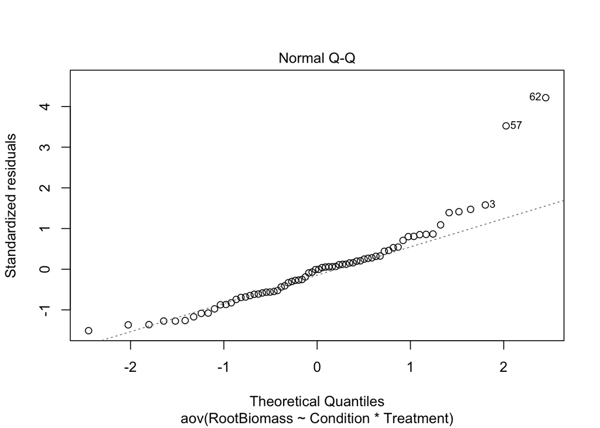

```r
# normality test
plot(rootbiomass.aov, 2)
```

```r
rootbiomass.residuals <- residuals(object = rootbiomass.aov)
shapiro.test(x = rootbiomass.residuals)
```

```
##
##  Shapiro-Wilk normality test
##
## data:  rootbiomass.residuals
## W = 0.87113, p-value = 3.343e-06
```

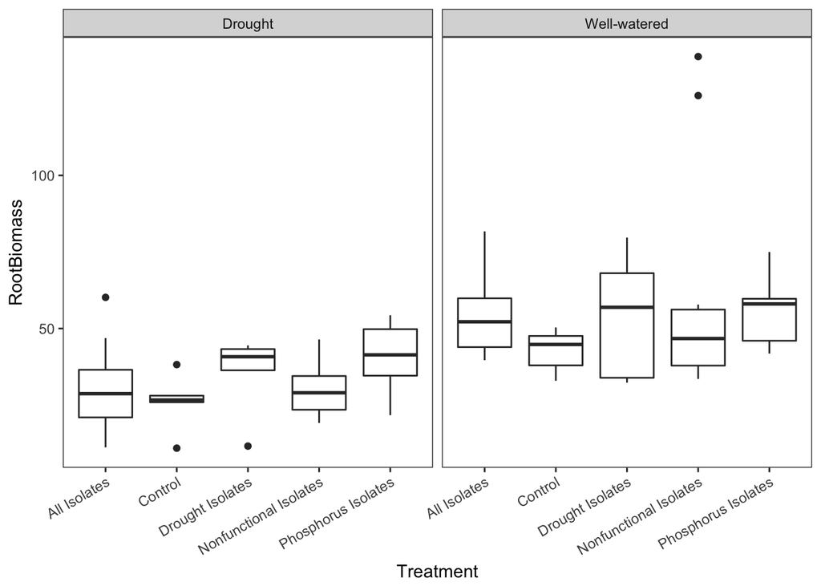

```r
ggplot(data = biomass, aes(x = Treatment, y = RootBiomass)) + geom_boxplot() + facet_grid(. ~ Condition) + mytheme
```

### Root:Shoot

```r
rootshoot.aov <- aov(RootShoot ~ Condition*Treatment, data = biomass)
summary(rootshoot.aov)
```

```
##                     Df Sum Sq Mean Sq F value Pr(>F)
## Condition            1   3.67   3.669   0.738  0.394
## Treatment            4  46.80  11.699   2.354  0.064 .
## Condition:Treatment  4  35.75   8.938   1.798  0.141
## Residuals           60 298.26   4.971
## ---
## Signif. codes:  0 '***' 0.001 '**' 0.01 '*' 0.05 '.' 0.1 ' ' 1
```

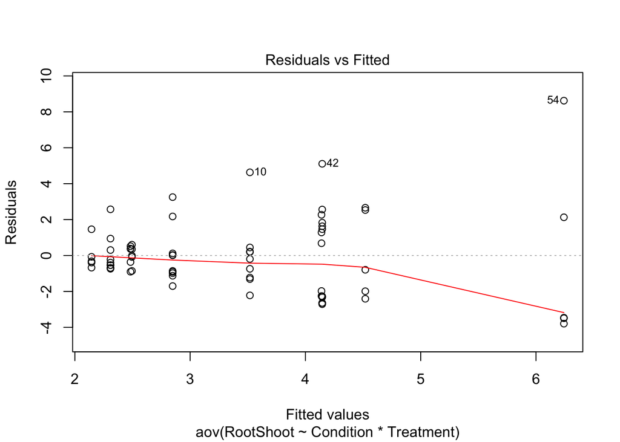

```r
# homogeneity of variance
plot(rootshoot.aov, 1)
```

```r
leveneTest(RootShoot ~ Condition*Treatment, data = biomass)
```

|  | Df | F value | Pr(>F) |
| --- | --- | --- | --- |
| group | 9 | 2.21764 | 0.03296079 |
|  | 60 | NA | NA |

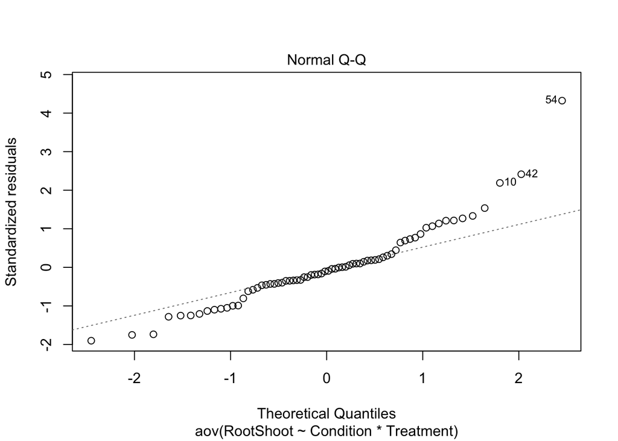

```r
# normality test
plot(rootshoot.aov, 2)
```

```r
rootshoot.residuals <- residuals(object = rootshoot.aov)
shapiro.test(x = rootshoot.residuals)
```

```
##
##  Shapiro-Wilk normality test
##
## data:  rootshoot.residuals
## W = 0.92488, p-value = 0.0004345
```

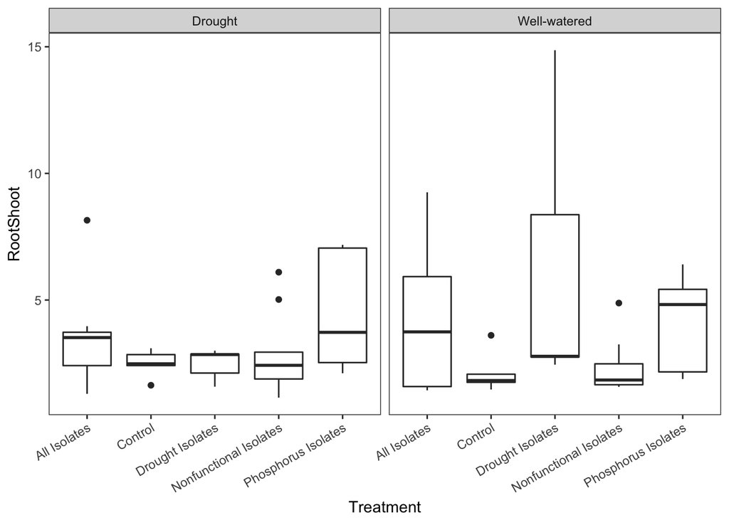

```r
ggplot(data = biomass, aes(x = Treatment, y = RootShoot)) + geom_boxplot() + facet_grid(. ~ Condition) + mytheme
```

### RMF

```r
rmf.aov <- aov(RMF~ Condition*Treatment, data = biomass)
summary(rmf.aov)
```

```
##                     Df Sum Sq  Mean Sq F value Pr(>F)
## Condition            1 0.0004 0.000362   0.042 0.8390
## Treatment            4 0.0838 0.020950   2.406 0.0594 .
## Condition:Treatment  4 0.0323 0.008080   0.928 0.4539
## Residuals           60 0.5225 0.008708
## ---
## Signif. codes:  0 '***' 0.001 '**' 0.01 '*' 0.05 '.' 0.1 ' ' 1
```

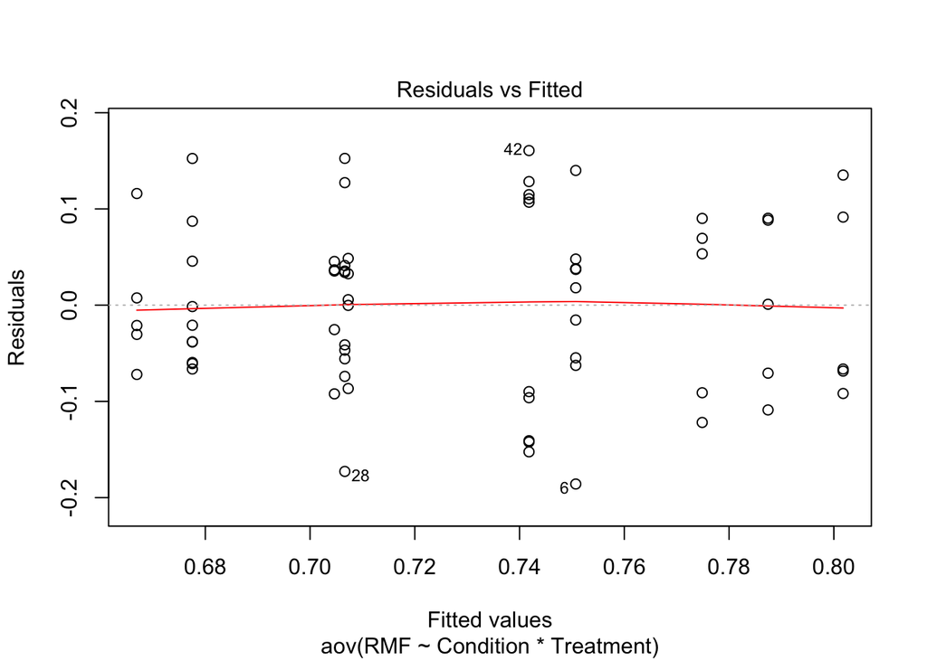

```r
# homogeneity of variance
plot(rmf.aov, 1)
```

```r
leveneTest(RMF ~ Condition*Treatment, data = biomass)
```

|  | Df | F value | Pr(>F) |
| --- | --- | --- | --- |
| group | 9 | 1.639685 | 0.1245309 |
|  | 60 | NA | NA |

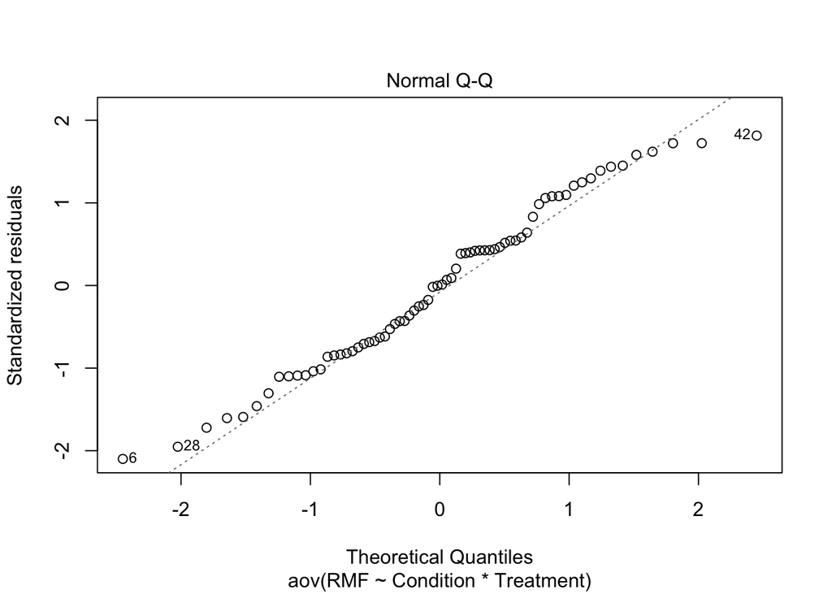

```r
# normality test
plot(rmf.aov, 2)
```

```r
rmf.residuals <- residuals(object = rmf.aov)
shapiro.test(x = rmf.residuals)
```

```
##
##  Shapiro-Wilk normality test
##
## data:  rmf.residuals
## W = 0.97593, p-value = 0.1964
```

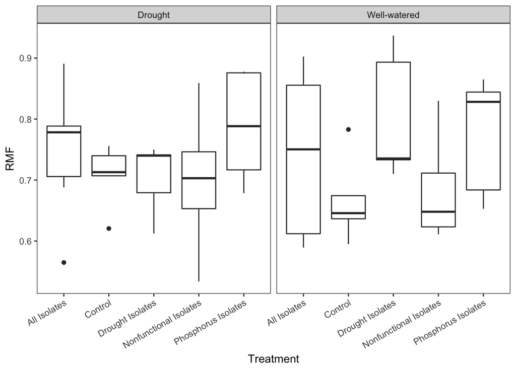

```r
ggplot(data = biomass, aes(x = Treatment, y = RMF)) + geom_boxplot() + facet_grid(. ~ Condition) + mytheme
```

# Physiology Measurements

## Malic Acid Titrations

```r
library(tidyverse)
clusia.malic <- read.csv("~/Documents/LabStats/Clusia/MalicAcid.csv", header = TRUE , sep = ",", stringsAsFactors = TRUE, na.strings = "na")
```

### Malic Acid Controls

```r
# Week 0
wk0.controls <- clusia.malic %>%
  filter(Treatment == "Control" | Treatment == "Control Mock") %>%
  filter(Week == "Wk_0") %>%
  arrange(Condition, Treatment)

malic.control0.aov <- aov(MalicAverage ~ Condition * Treatment, data = wk0.controls)
summary(malic.control0.aov) # not sigificant between autoclaved and inoculated controls
```

```
##                     Df Sum Sq Mean Sq F value Pr(>F)
## Condition            1   1769    1769   0.409  0.546
## Treatment            1      2       2   0.000  0.983
## Condition:Treatment  1     43      43   0.010  0.923
## Residuals            6  25922    4320
## 1 observation deleted due to missingness
```

```r
# Week 2
wk2.controls <- clusia.malic %>%
  filter(Treatment == "Control" | Treatment == "Control Mock") %>%
  filter(Week == "Wk_2") %>%
  arrange(Condition, Treatment)

malic.control2.aov <- aov(MalicAverage ~ Condition * Treatment, data = wk2.controls)
summary(malic.control2.aov) # not sigificant between autoclaved and inoculated controls
```

```
##                     Df Sum Sq Mean Sq F value  Pr(>F)
## Condition            1 150438  150438  11.524 0.00944 **
## Treatment            1  27151   27151   2.080 0.18724
## Condition:Treatment  1   1951    1951   0.149 0.70916
## Residuals            8 104439   13055
## ---
## Signif. codes:  0 '***' 0.001 '**' 0.01 '*' 0.05 '.' 0.1 ' ' 1
```

```r
# Week 4
wk4.controls <- clusia.malic %>%
  filter(Treatment == "Control" | Treatment == "Control Mock") %>%
  filter(Week == "Wk_4") %>%
  arrange(Condition, Treatment)

malic.control4.aov <- aov(MalicAverage ~ Condition * Treatment, data = wk4.controls)
summary(malic.control4.aov) # not sigificant between autoclaved and inoculated controls
```

```
##             Df Sum Sq Mean Sq F value Pr(>F)
## Condition    1  81042   81042   2.159  0.202
## Treatment    1  19763   19763   0.526  0.501
## Residuals    5 187700   37540
```

```r
# Week 6
wk6.controls <- clusia.malic %>%
  filter(Treatment == "Control" | Treatment == "Control Mock") %>%
  filter(Week == "Wk_6") %>%
  arrange(Condition, Treatment)

malic.control6.aov <- aov(MalicAverage ~ Condition * Treatment, data = wk6.controls)
summary(malic.control6.aov) # not sigificant between autoclaved and inoculated controls
```

```
##                     Df Sum Sq Mean Sq F value Pr(>F)
## Condition            1   4834    4834   0.713  0.426
## Treatment            1   1836    1836   0.271  0.619
## Condition:Treatment  1   4706    4706   0.695  0.432
## Residuals            7  47427    6775
```

```r
# Week 8
wk8.controls <- clusia.malic %>%
  filter(Treatment == "Control" | Treatment == "Control Mock") %>%
  filter(Week == "Wk_8") %>%
  arrange(Condition, Treatment)

malic.control8.aov <- aov(MalicAverage ~ Condition * Treatment, data = wk8.controls)
summary(malic.control8.aov) # not sigificant between autoclaved and inoculated controls
```

```
##                     Df Sum Sq Mean Sq F value   Pr(>F)
## Condition            1 516094  516094 141.946 2.26e-06 ***
## Treatment            1    112     112   0.031    0.865
## Condition:Treatment  1     10      10   0.003    0.960
## Residuals            8  29087    3636
## ---
## Signif. codes:  0 '***' 0.001 '**' 0.01 '*' 0.05 '.' 0.1 ' ' 1
```

```r
# removing Control Mock & fixing 'Null isolates'
clusia.malic <- clusia.malic %>%
  filter(Treatment != "Control Mock")

clusia.malic$Treatment[clusia.malic$Treatment == "Null Isolates"] <- "Nonfunctional Isolates"
clusia.malic$Treatment[clusia.malic$Treatment == "Null_Isolates"] <- "Nonfunctional Isolates"
clusia.malic$Treatment[clusia.malic$Treatment == "All_Isolates"] <- "All Isolates"
clusia.malic$Treatment[clusia.malic$Treatment == "Drought_Isolates"] <- "Drought Isolates"
clusia.malic$Treatment[clusia.malic$Treatment == "Phosphorus_Isolates"] <- "Phosphorus Isolates"

# arranging by Week, Water, and Treatment
clusia.malic <- clusia.malic %>%
  arrange(Week, Condition, Treatment)
```

### Malic Acid Summary Stats

```r
malic.sum <- clusia.malic %>%
  group_by(Week, Condition, Treatment) %>%
  summarise(n = n(),
            mean_malic = mean(MalicAverage, na.rm = TRUE),
            sd_malic = sd(MalicAverage, na.rm = TRUE),
            se = sd(MalicAverage, na.rm = TRUE)/sqrt(n()))
View(malic.sum)
```

### Malic Acid ANOVAs

```r
# Week 0
malic.wk0 <- clusia.malic %>%
  filter(Week == "Wk_0")

malic.wk0.aov <- aov(MalicAverage ~ Condition * Treatment, data = malic.wk0)
summary(malic.wk0.aov) # not sigificant between treatment
```

```
##                     Df Sum Sq Mean Sq F value Pr(>F)
## Condition            1     71      71   0.016  0.901
## Treatment            5  12528    2506   0.564  0.726
## Condition:Treatment  4  10351    2588   0.582  0.680
## Residuals           16  71089    4443
## 3 observations deleted due to missingness
```

```r
# Week 2
malic.wk2 <- clusia.malic %>%
  filter(Week == "Wk_2")

malic.wk2.aov <- aov(MalicAverage ~ Condition * Treatment, data = malic.wk2)
summary(malic.wk2.aov) # significant drought effect
```

```
##                     Df Sum Sq Mean Sq F value   Pr(>F)
## Condition            1 287098  287098  36.643 8.02e-06 ***
## Treatment            4  34396    8599   1.098  0.38626
## Condition:Treatment  4 211782   52946   6.757  0.00147 **
## Residuals           19 148867    7835
## ---
## Signif. codes:  0 '***' 0.001 '**' 0.01 '*' 0.05 '.' 0.1 ' ' 1
## 1 observation deleted due to missingness
```

```r
# Week 4
malic.wk4 <- clusia.malic %>%
  filter(Week == "Wk_4")

malic.wk4.aov <- aov(MalicAverage ~ Condition * Treatment, data = malic.wk4)
summary(malic.wk4.aov) # sigificant drought effect
```

```
##                     Df Sum Sq Mean Sq F value  Pr(>F)
## Condition            1 802650  802650  12.430 0.00306 **
## Treatment            4 133019   33255   0.515 0.72590
## Condition:Treatment  4  65953   16488   0.255 0.90188
## Residuals           15 968573   64572
## ---
## Signif. codes:  0 '***' 0.001 '**' 0.01 '*' 0.05 '.' 0.1 ' ' 1
```

```r
# Week 6
malic.wk6 <- clusia.malic %>%
  filter(Week == "Wk_6")

malic.wk6.aov <- aov(MalicAverage ~ Condition * Treatment, data = malic.wk6)
summary(malic.wk6.aov) # sigificant drought effect
```

```
##                     Df Sum Sq Mean Sq F value   Pr(>F)
## Condition            1 152326  152326  17.672 0.000437 ***
## Treatment            4  73866   18467   2.142 0.113048
## Condition:Treatment  4 168945   42236   4.900 0.006424 **
## Residuals           20 172390    8619
## ---
## Signif. codes:  0 '***' 0.001 '**' 0.01 '*' 0.05 '.' 0.1 ' ' 1
```

```r
# Week 8
malic.wk8 <- clusia.malic %>%
  filter(Week == "Wk_8")

malic.wk8.aov <- aov(MalicAverage ~ Condition * Treatment, data = malic.wk8)
summary(malic.wk8.aov) # significant drought effect and microbial effect
```

```
##                     Df Sum Sq Mean Sq F value   Pr(>F)
## Condition            1 432864  432864  26.157 5.29e-05 ***
## Treatment            4 227707   56927   3.440    0.027 *
## Condition:Treatment  4  77288   19322   1.168    0.355
## Residuals           20 330968   16548
## ---
## Signif. codes:  0 '***' 0.001 '**' 0.01 '*' 0.05 '.' 0.1 ' ' 1
```

```r
TukeyHSD(malic.wk8.aov)
```

```
##   Tukey multiple comparisons of means
##     95% family-wise confidence level
##
## Fit: aov(formula = MalicAverage ~ Condition * Treatment, data = malic.wk8)
##
## $Condition
##                        diff      lwr      upr    p adj
## Well-watered-Drought 240.24 142.2563 338.2237 5.29e-05
##
## $Treatment
##                                                  diff         lwr
## Control-All Isolates                        134.41667  -87.828986
## Drought Isolates-All Isolates               -10.90000 -233.145653
## Nonfunctional Isolates-All Isolates         218.45000   -3.795653
## Phosphorus Isolates-All Isolates             45.50000 -176.745653
## Drought Isolates-Control                   -145.31667 -367.562319
## Nonfunctional Isolates-Control               84.03333 -138.212319
## Phosphorus Isolates-Control                 -88.91667 -311.162319
## Nonfunctional Isolates-Drought Isolates     229.35000    7.104347
## Phosphorus Isolates-Drought Isolates         56.40000 -165.845653
## Phosphorus Isolates-Nonfunctional Isolates -172.95000 -395.195653
##                                                  upr     p adj
## Control-All Isolates                       356.66232 0.3955729
## Drought Isolates-All Isolates              211.34565 0.9998858
## Nonfunctional Isolates-All Isolates        440.69565 0.0554856
## Phosphorus Isolates-All Isolates           267.74565 0.9713947
## Drought Isolates-Control                    76.92899 0.3217188
## Nonfunctional Isolates-Control             306.27899 0.7883022
## Phosphorus Isolates-Control                133.32899 0.7529027
## Nonfunctional Isolates-Drought Isolates    451.59565 0.0410511
## Phosphorus Isolates-Drought Isolates       278.64565 0.9392296
## Phosphorus Isolates-Nonfunctional Isolates  49.29565 0.1769778
##
## $`Condition:Treatment`
##                                                                             diff
## Well-watered:All Isolates-Drought:All Isolates                        176.266667
## Drought:Control-Drought:All Isolates                                   14.266667
## Well-watered:Control-Drought:All Isolates                             430.833333
## Drought:Drought Isolates-Drought:All Isolates                           4.433333
## Well-watered:Drought Isolates-Drought:All Isolates                    150.033333
```

[output cut: 163 more lines]

```
## Well-watered:Drought Isolates-Drought:Drought Isolates               0.9178606
## Drought:Nonfunctional Isolates-Drought:Drought Isolates              0.8814053
## Well-watered:Nonfunctional Isolates-Drought:Drought Isolates         0.0108926
## Drought:Phosphorus Isolates-Drought:Drought Isolates                 0.9999893
## Well-watered:Phosphorus Isolates-Drought:Drought Isolates            0.5806005
## Drought:Nonfunctional Isolates-Well-watered:Drought Isolates         1.0000000
## Well-watered:Nonfunctional Isolates-Well-watered:Drought Isolates    0.1762492
## Drought:Phosphorus Isolates-Well-watered:Drought Isolates            0.9908546
## Well-watered:Phosphorus Isolates-Well-watered:Drought Isolates       0.9994979
## Well-watered:Nonfunctional Isolates-Drought:Nonfunctional Isolates   0.2101330
## Drought:Phosphorus Isolates-Drought:Nonfunctional Isolates           0.9820104
## Well-watered:Phosphorus Isolates-Drought:Nonfunctional Isolates      0.9998729
## Drought:Phosphorus Isolates-Well-watered:Nonfunctional Isolates      0.0264265
## Well-watered:Phosphorus Isolates-Well-watered:Nonfunctional Isolates 0.4759768
## Well-watered:Phosphorus Isolates-Drought:Phosphorus Isolates         0.8187525
```

```r
clusia.boxplot <- ggplot(data = clusia.malic, aes(x = Treatment, y = MalicAverage, fill = Condition)) + geom_boxplot() + geom_point(aes(fill = Condition), size = 2, shape = 21, position = position_jitterdodge()) + facet_grid(. ~ Week)

clusia.boxplot <- clusia.boxplot + theme_bw() +scale_fill_manual(values=c("indianred3", "cadetblue3"), breaks=c("Well-watered", "Drought"),labels=c("Well-watered", "Drought")) + theme(panel.grid.major = element_blank(), panel.grid.minor = element_blank()) + theme(axis.title.x = element_blank()) + theme(axis.text.x = element_text(angle = 45, hjust = 1, vjust = 1)) + theme(legend.position = c(0.095, 0.9))

clusia.boxplot <- clusia.boxplot + ylab(expression(Malic~Acid~Concentration~(mu~mol~H~g^{-1})))

malic.wk8.aov <- aov(MalicAverage ~ Condition * Treatment, data = malic.wk8)
summary(malic.wk8.aov) # significant drought effect and microbial effect
```

```
##                     Df Sum Sq Mean Sq F value   Pr(>F)
## Condition            1 432864  432864  26.157 5.29e-05 ***
## Treatment            4 227707   56927   3.440    0.027 *
## Condition:Treatment  4  77288   19322   1.168    0.355
## Residuals           20 330968   16548
## ---
## Signif. codes:  0 '***' 0.001 '**' 0.01 '*' 0.05 '.' 0.1 ' ' 1
```

At Week 0, both well-watered and drought plants show no difference in malic acid concentrations as expected. However, as the drought trial progresses, well-watered plants and drought plants begin to diverge significantly at Week 2 (p-value < 0.001). Higher amounts of malic acid in well-watered plants indicate higher CAM activity, which is in contrast with hypotheses that CAM activity would be highest in drought plants due to experiencing drought stress. Furthermore, there was no significant effect of microbial community until the last week (p- value < 0.05) with no interaction term, suggesting that availability of water is still the dominant driver of malic acid concentration. Tukeys HSD results indicate that although the differences in microbial communities are different, that these differences are occuring between well-watered microbial communities versus droughted microbial communities, verifying that the water availability is driving differences between plants and not the composition of the the microbial communities themselves.

## Lipid Peroxidation Assay

```r
clusia.lipid <- read.csv("~/Documents/Git/clusia_droughtexperiment/LipidPeroxidation.csv", header = TRUE , sep = ",", stringsAsFactors = TRUE, na.strings = "na")
```

### Lipid Peroxidation Controls

```r
# Week 0
wk0.controls <- clusia.lipid %>%
  filter(Treatment == "Control" | Treatment == "Control Mock") %>%
  filter(Week == "Wk_0") %>%
  arrange(Condition, Treatment)

lipid.control0.aov <- aov(LipidPerox ~ Condition * Treatment, data = wk0.controls)
summary(lipid.control0.aov) # not sigificant between autoclaved and inoculated controls
```

```
##                     Df Sum Sq Mean Sq F value Pr(>F)
## Condition            1    1.0    1.05   0.019  0.895
## Treatment            1   20.1   20.07   0.357  0.569
## Condition:Treatment  1   44.0   44.03   0.782  0.406
## Residuals            7  393.9   56.27
```

```r
# Week 2
wk2.controls <- clusia.lipid %>%
  filter(Treatment == "Control" | Treatment == "Control Mock") %>%
  filter(Week == "Wk_2") %>%
  arrange(Condition, Treatment)

lipid.control2.aov <- aov(LipidPerox ~ Condition * Treatment, data = wk2.controls)
summary(lipid.control2.aov) # not sigificant between autoclaved and inoculated controls
```

```
##                     Df Sum Sq Mean Sq F value Pr(>F)
## Condition            1   14.1   14.07   0.274  0.615
## Treatment            1   42.4   42.42   0.826  0.390
## Condition:Treatment  1   41.9   41.95   0.817  0.393
## Residuals            8  410.9   51.36
```

```r
# Week 4
wk4.controls <- clusia.lipid %>%
  filter(Treatment == "Control" | Treatment == "Control Mock") %>%
  filter(Week == "Wk_4") %>%
  arrange(Condition, Treatment)

lipid.control4.aov <- aov(LipidPerox ~ Condition * Treatment, data = wk4.controls)
summary(lipid.control4.aov) # not sigificant between autoclaved and inoculated controls
```

```
##                     Df Sum Sq Mean Sq F value Pr(>F)
## Condition            1   30.3   30.30   0.167  0.695
## Treatment            1   19.8   19.76   0.109  0.751
## Condition:Treatment  1   68.7   68.65   0.378  0.558
## Residuals            7 1272.0  181.71
```

```r
# Week 6
wk6.controls <- clusia.lipid %>%
  filter(Treatment == "Control" | Treatment == "Control Mock") %>%
  filter(Week == "Wk_6") %>%
  arrange(Condition, Treatment)

lipid.control6.aov <- aov(LipidPerox ~ Condition * Treatment, data = wk6.controls)
summary(lipid.control6.aov) # not sigificant between autoclaved and inoculated controls
```

```
##                     Df Sum Sq Mean Sq F value Pr(>F)
## Condition            1   1362  1362.1   1.763  0.226
## Treatment            1    475   474.5   0.614  0.459
## Condition:Treatment  1     86    86.4   0.112  0.748
## Residuals            7   5409   772.6
```

```r
# Week 8
wk8.controls <- clusia.lipid %>%
  filter(Treatment == "Control" | Treatment == "Control Mock") %>%
  filter(Week == "Wk_8") %>%
  arrange(Condition, Treatment)

lipid.control8.aov <- aov(LipidPerox ~ Condition * Treatment, data = wk8.controls)
summary(lipid.control8.aov) # not sigificant between autoclaved and inoculated controls
```

```
##                     Df Sum Sq Mean Sq F value Pr(>F)
## Condition            1 1943.2  1943.2   9.942 0.0135 *
## Treatment            1   79.8    79.8   0.408 0.5408
## Condition:Treatment  1    5.9     5.9   0.030 0.8658
## Residuals            8 1563.6   195.5
## ---
## Signif. codes:  0 '***' 0.001 '**' 0.01 '*' 0.05 '.' 0.1 ' ' 1
```

```r
# removing Control Mock
clusia.lipid <- clusia.lipid %>%
  filter(Treatment != "Control Mock")
View(clusia.lipid)

# arranging by Week, Water, and Treatment
clusia.lipid <- clusia.lipid %>%
  arrange(Week, Condition, Treatment)
```

### Lipid Peroxidation Summary Stats

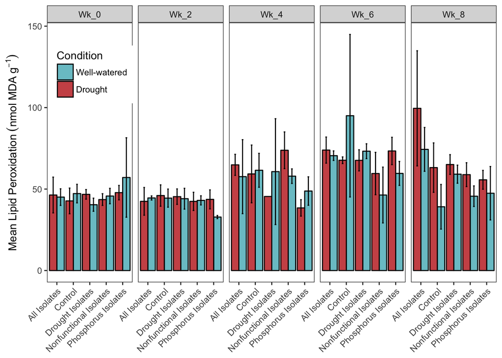

```r
lipid.sum <- clusia.lipid %>%
  group_by(Week, Condition, Treatment) %>%
  summarise(n = n(),
            mean_lipid = mean(LipidPerox, na.rm = TRUE),
            sd_lipid = sd(LipidPerox, na.rm = TRUE),
            se = sd(LipidPerox, na.rm = TRUE)/sqrt(n()))
View(lipid.sum)

lipid.errobars <- ggplot(data = lipid.sum, aes(x = Treatment, y = mean_lipid, fill = Condition)) + geom_bar(stat = "identity", color = "black", position = position_dodge(0.9)) + geom_errorbar(aes(ymin = mean_lipid-sd_lipid, ymax = mean_lipid+sd_lipid), width = 0.2, position = position_dodge(0.9)) + facet_grid(. ~ Week)

lipid.errobars <- lipid.errobars + theme_bw() + scale_fill_manual(values=c("indianred3", "cadetblue3"), breaks=c("Well-watered", "Drought"),labels=c("Well-watered", "Drought")) + theme(panel.grid.major = element_blank(), panel.grid.minor = element_blank()) + theme(axis.title.x = element_blank()) + theme(axis.text.x = element_text(angle = 45, hjust = 1, vjust = 1)) + theme(legend.position = c(0.1, 0.8)) + ylab(expression(Mean~Lipid~Peroxidation~(nmol~MDA~g^{-1})))

lipid.errobars
```

### Lipid Peroxidation ANOVAs

```r
# Week 0
lipid.wk0 <- clusia.lipid %>%
  filter(Week == "Wk_0")

lipid.wk0.aov <- aov(LipidPerox ~ Condition * Treatment, data = lipid.wk0)
summary(lipid.wk0.aov)
```

```
##                     Df Sum Sq Mean Sq F value Pr(>F)
## Condition            1   15.8   15.81   0.173  0.682
## Treatment            4  285.4   71.35   0.781  0.551
## Condition:Treatment  4  222.9   55.72   0.610  0.660
## Residuals           20 1827.3   91.36
```

```r
# Week 2
lipid.wk2 <- clusia.lipid %>%
  filter(Week == "Wk_2")

lipid.wk2.aov <- aov(LipidPerox ~ Condition * Treatment, data = lipid.wk2)
summary(lipid.wk2.aov)
```

```
##                     Df Sum Sq Mean Sq F value Pr(>F)
## Condition            1   38.6   38.64   1.297  0.269
## Treatment            4  205.3   51.33   1.723  0.186
## Condition:Treatment  4  126.6   31.65   1.062  0.402
## Residuals           19  566.0   29.79
```

```r
# Week 4
lipid.wk4 <- clusia.lipid %>%
  filter(Week == "Wk_4")

lipid.wk4.aov <- aov(LipidPerox ~ Condition * Treatment, data = lipid.wk4)
summary(lipid.wk4.aov)
```

```
##                     Df Sum Sq Mean Sq F value Pr(>F)
## Condition            1     11    11.4   0.054  0.820
## Treatment            4   1702   425.6   2.001  0.143
## Condition:Treatment  4    774   193.5   0.909  0.482
## Residuals           16   3404   212.7
```

```r
# Week 6
lipid.wk6 <- clusia.lipid %>%
  filter(Week == "Wk_6")

lipid.wk6.aov <- aov(LipidPerox ~ Condition * Treatment, data = lipid.wk6)
summary(lipid.wk6.aov)
```

```
##                     Df Sum Sq Mean Sq F value Pr(>F)
## Condition            1      3     2.9   0.009 0.9234
## Treatment            4   2790   697.5   2.261 0.0969 .
## Condition:Treatment  4   1515   378.9   1.228 0.3291
## Residuals           21   6479   308.5
## ---
## Signif. codes:  0 '***' 0.001 '**' 0.01 '*' 0.05 '.' 0.1 ' ' 1
```

```r
lipid.wk6.aov <- aov(LipidPerox ~ Condition * Treatment, data = lipid.wk6)
summary(lipid.wk6.aov) # significant <0.1 microbial effect
```

```
##                     Df Sum Sq Mean Sq F value Pr(>F)
## Condition            1      3     2.9   0.009 0.9234
## Treatment            4   2790   697.5   2.261 0.0969 .
## Condition:Treatment  4   1515   378.9   1.228 0.3291
## Residuals           21   6479   308.5
## ---
## Signif. codes:  0 '***' 0.001 '**' 0.01 '*' 0.05 '.' 0.1 ' ' 1
```

```r
# Week 8
lipid.wk8 <- clusia.lipid %>%
  filter(Week == "Wk_8")

lipid.wk8.aov <- aov(LipidPerox ~ Condition * Treatment, data = lipid.wk8)
summary(lipid.wk8.aov) # significant drought effect, significant microbial effect
```

```
##                     Df Sum Sq Mean Sq F value  Pr(>F)
## Condition            1   1762  1762.2   7.625 0.01204 *
## Treatment            4   5627  1406.8   6.087 0.00226 **
## Condition:Treatment  4    475   118.7   0.513 0.72659
## Residuals           20   4622   231.1
## ---
## Signif. codes:  0 '***' 0.001 '**' 0.01 '*' 0.05 '.' 0.1 ' ' 1
```

```r
TukeyHSD(lipid.wk8.aov)
```

```
##   Tukey multiple comparisons of means
##     95% family-wise confidence level
##
## Fit: aov(formula = LipidPerox ~ Condition * Treatment, data = lipid.wk8)
##
## $Condition
##                           diff       lwr       upr     p adj
## Well-watered-Drought -15.32833 -26.90781 -3.748853 0.0120432
##
## $Treatment
##                                                   diff       lwr       upr
## Control-All Isolates                       -35.8098333 -62.07429 -9.545381
## Drought Isolates-All Isolates              -24.8580000 -51.12245  1.406452
## Nonfunctional Isolates-All Isolates        -34.7236667 -60.98812 -8.459214
## Phosphorus Isolates-All Isolates           -35.3978333 -61.66229 -9.133381
## Drought Isolates-Control                    10.9518333 -15.31262 37.216286
## Nonfunctional Isolates-Control               1.0861667 -25.17829 27.350619
## Phosphorus Isolates-Control                  0.4120000 -25.85245 26.676452
## Nonfunctional Isolates-Drought Isolates     -9.8656667 -36.13012 16.398786
## Phosphorus Isolates-Drought Isolates       -10.5398333 -36.80429 15.724619
## Phosphorus Isolates-Nonfunctional Isolates  -0.6741667 -26.93862 25.590286
##                                                p adj
## Control-All Isolates                       0.0047088
## Drought Isolates-All Isolates              0.0690768
## Nonfunctional Isolates-All Isolates        0.0062166
## Phosphorus Isolates-All Isolates           0.0052328
## Drought Isolates-Control                   0.7244673
## Nonfunctional Isolates-Control             0.9999421
## Phosphorus Isolates-Control                0.9999988
## Nonfunctional Isolates-Drought Isolates    0.7921729
## Phosphorus Isolates-Drought Isolates       0.7508927
## Phosphorus Isolates-Nonfunctional Isolates 0.9999914
##
## $`Condition:Treatment`
##                                                                            diff
## Well-watered:All Isolates-Drought:All Isolates                       -25.200333
## Drought:Control-Drought:All Isolates                                 -36.388667
## Well-watered:Control-Drought:All Isolates                            -60.431333
## Drought:Drought Isolates-Drought:All Isolates                        -34.496667
## Well-watered:Drought Isolates-Drought:All Isolates                   -40.419667
```

[output cut: 163 more lines]

```
## Well-watered:Drought Isolates-Drought:Drought Isolates               0.9999647
## Drought:Nonfunctional Isolates-Drought:Drought Isolates              0.9999474
## Well-watered:Nonfunctional Isolates-Drought:Drought Isolates         0.8488137
## Drought:Phosphorus Isolates-Drought:Drought Isolates                 0.9985395
## Well-watered:Phosphorus Isolates-Drought:Drought Isolates            0.9068716
## Drought:Nonfunctional Isolates-Well-watered:Drought Isolates         1.0000000
## Well-watered:Nonfunctional Isolates-Well-watered:Drought Isolates    0.9803061
## Drought:Phosphorus Isolates-Well-watered:Drought Isolates            0.9999997
## Well-watered:Phosphorus Isolates-Well-watered:Drought Isolates       0.9925906
## Well-watered:Nonfunctional Isolates-Drought:Nonfunctional Isolates   0.9828754
## Drought:Phosphorus Isolates-Drought:Nonfunctional Isolates           0.9999998
## Well-watered:Phosphorus Isolates-Drought:Nonfunctional Isolates      0.9937820
## Drought:Phosphorus Isolates-Well-watered:Nonfunctional Isolates      0.9975143
## Well-watered:Phosphorus Isolates-Well-watered:Nonfunctional Isolates 1.0000000
## Well-watered:Phosphorus Isolates-Drought:Phosphorus Isolates         0.9994682
```

```r
lipid.wk8.aov <- aov(LipidPerox ~ Condition * Treatment, data = lipid.wk8)
summary(lipid.wk8.aov) # significant drought effect, significant microbial effect
```

```
##                     Df Sum Sq Mean Sq F value  Pr(>F)
## Condition            1   1762  1762.2   7.625 0.01204 *
## Treatment            4   5627  1406.8   6.087 0.00226 **
## Condition:Treatment  4    475   118.7   0.513 0.72659
## Residuals           20   4622   231.1
## ---
## Signif. codes:  0 '***' 0.001 '**' 0.01 '*' 0.05 '.' 0.1 ' ' 1
```

```r
lipid.boxplot <- ggplot(data = clusia.lipid, aes(x = Treatment, y = LipidPerox, fill = Condition)) + geom_boxplot() + geom_point(aes(fill = Condition), size = 2, shape = 21, position = position_jitterdodge()) + facet_grid(. ~ Week)

lipid.boxplot <- lipid.boxplot + theme_bw() +scale_fill_manual(values=c("indianred3", "cadetblue3"), breaks=c("Well-watered", "Drought"),labels=c("Well-watered", "Drought")) + theme(panel.grid.major = element_blank(), panel.grid.minor = element_blank()) + theme(axis.title.x = element_blank()) + theme(axis.text.x = element_text(angle = 45, hjust = 1, vjust = 1)) + theme(legend.position = c(0.1, 0.8)) + ylab(expression(Lipid~Peroxidation~(nmol~MDA~g^{-1})))

lipid.boxplot <- lipid.boxplot + theme_bw() +scale_fill_manual(values=c("indianred3", "cadetblue3"), breaks=c("Well-watered", "Drought"),labels=c("Well-watered", "Drought")) + theme(panel.grid.major = element_blank(), panel.grid.minor = element_blank()) + theme(axis.title.x = element_blank()) + theme(axis.text.x = element_text(angle = 45, hjust = 1, vjust = 1)) + theme(legend.position = c(0.1, 0.8))
```

[output not shown]

```r
pdf("LipidPerox_Boxplot.pdf")
plot(lipid.boxplot)
dev.off()
```

## Proline Assay

```r
clusia.proline <- read.csv("~/Documents/Git/clusia_droughtexperiment/Proline.csv", header = TRUE , sep = ",", stringsAsFactors = TRUE, na.strings = "na")
```

### Proline Controls

```r
# Week 0
wk0.controls <- clusia.proline %>%
  filter(Treatment == "Control" | Treatment == "Control Mock") %>%
  filter(Week == "Wk_0") %>%
  arrange(Condition, Treatment)

proline.control0.aov <- aov(Proline ~ Condition * Treatment, data = wk0.controls)
summary(proline.control0.aov) # not sigificant between autoclaved and inoculated controls
```

```
##                     Df Sum Sq Mean Sq F value Pr(>F)
## Condition            1   3.96   3.960   0.221  0.653
## Treatment            1  20.46  20.458   1.141  0.321
## Condition:Treatment  1   7.39   7.386   0.412  0.541
## Residuals            7 125.53  17.933
```

```r
# Week 2
wk2.controls <- clusia.proline %>%
  filter(Treatment == "Control" | Treatment == "Control Mock") %>%
  filter(Week == "Wk_2") %>%
  arrange(Condition, Treatment)

proline.control2.aov <- aov(Proline ~ Condition * Treatment, data = wk2.controls)
summary(proline.control2.aov) # not sigificant between autoclaved and inoculated controls
```

```
##                     Df Sum Sq Mean Sq F value Pr(>F)
## Condition            1 161.52  161.52   6.444 0.0348 *
## Treatment            1   0.12    0.12   0.005 0.9456
## Condition:Treatment  1   2.88    2.88   0.115 0.7433
## Residuals            8 200.52   25.06
## ---
## Signif. codes:  0 '***' 0.001 '**' 0.01 '*' 0.05 '.' 0.1 ' ' 1
```

```r
# Week 4
wk4.controls <- clusia.proline %>%
  filter(Treatment == "Control" | Treatment == "Control Mock") %>%
  filter(Week == "Wk_4") %>%
  arrange(Condition, Treatment)

proline.control4.aov <- aov(Proline ~ Condition * Treatment, data = wk4.controls)
summary(proline.control4.aov) # significant interaction term + significant at < 0.1 for drought and microbial effect
```

```
##                     Df Sum Sq Mean Sq F value Pr(>F)
## Condition            1  21.15  21.146   4.229 0.0855 .
## Treatment            1  23.07  23.074   4.614 0.0753 .
## Condition:Treatment  1  30.84  30.845   6.168 0.0476 *
## Residuals            6  30.00   5.001
## ---
## Signif. codes:  0 '***' 0.001 '**' 0.01 '*' 0.05 '.' 0.1 ' ' 1
```

```r
# Week 6
wk6.controls <- clusia.proline %>%
  filter(Treatment == "Control" | Treatment == "Control Mock") %>%
  filter(Week == "Wk_6") %>%
  arrange(Condition, Treatment)

proline.control6.aov <- aov(Proline ~ Condition * Treatment, data = wk6.controls)
summary(proline.control6.aov) # significant drought effect
```

```
##                     Df Sum Sq Mean Sq F value  Pr(>F)
## Condition            1  510.5   510.5  17.722 0.00399 **
## Treatment            1    4.6     4.6   0.159 0.70219
## Condition:Treatment  1   51.8    51.8   1.800 0.22164
## Residuals            7  201.6    28.8
## ---
## Signif. codes:  0 '***' 0.001 '**' 0.01 '*' 0.05 '.' 0.1 ' ' 1
```

```r
# Week 8
wk8.controls <- clusia.proline %>%
  filter(Treatment == "Control" | Treatment == "Control Mock") %>%
  filter(Week == "Wk_8") %>%
  arrange(Condition, Treatment)

proline.control8.aov <- aov(Proline ~ Condition * Treatment, data = wk8.controls)
summary(proline.control8.aov) # significant drought effect
```

```
##                     Df Sum Sq Mean Sq F value   Pr(>F)
## Condition            1  544.8   544.8  36.230 0.000317 ***
## Treatment            1   13.0    13.0   0.867 0.379007
## Condition:Treatment  1   17.3    17.3   1.152 0.314418
## Residuals            8  120.3    15.0
## ---
## Signif. codes:  0 '***' 0.001 '**' 0.01 '*' 0.05 '.' 0.1 ' ' 1
```

```r
# removing Control Mock & fixing 'Null isolates'
clusia.lipid <- clusia.lipid %>%
  filter(Treatment != "Control Mock")

# arranging by Week, Water, and Treatment
clusia.lipid <- clusia.lipid %>%
  arrange(Week, Condition, Treatment)
```

### Proline Summary Stats

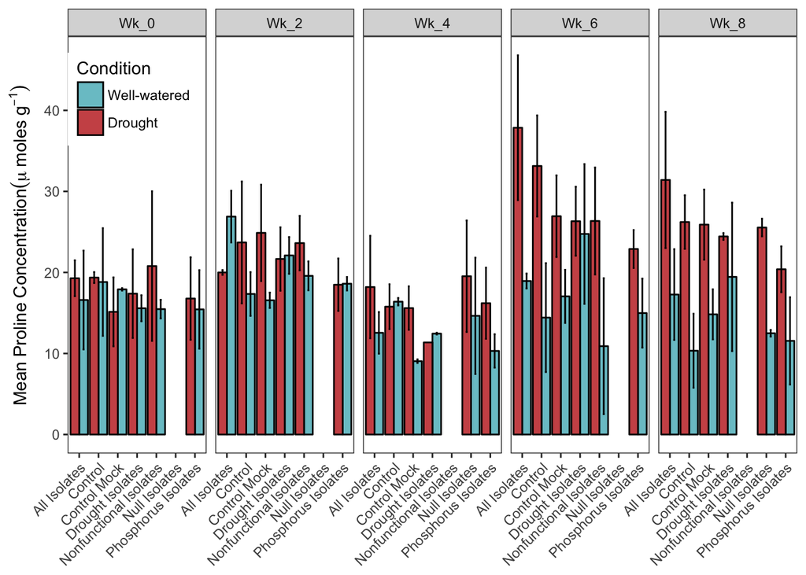

```r
proline.sum <- clusia.proline %>%
  group_by(Week, Condition, Treatment) %>%
  summarise(n = n(),
            mean_proline = mean(Proline, na.rm = TRUE),
            sd_proline = sd(Proline, na.rm = TRUE),
            se = sd(Proline, na.rm = TRUE)/sqrt(n()))
View(proline.sum)

proline.errobars <- ggplot(data = proline.sum, aes(x = Treatment, y = mean_proline, fill = Condition)) + geom_bar(stat = "identity", color = "black", position = position_dodge(0.9)) + geom_errorbar(aes(ymin = mean_proline-sd_proline, ymax = mean_proline+sd_proline), width = 0.2, position = position_dodge(0.9)) + facet_grid(. ~ Week)

proline.errobars <- proline.errobars + theme_bw() + scale_fill_manual(values=c("indianred3", "cadetblue3"), breaks=c("Well-watered", "Drought"),labels=c("Well-watered", "Drought")) + theme(panel.grid.major = element_blank(), panel.grid.minor = element_blank()) + theme(axis.title.x = element_blank()) + theme(axis.text.x = element_text(angle = 45, hjust = 1, vjust = 1)) + theme(legend.position = c(0.09, 0.85)) + ylab(expression(Mean~Proline~Concentration(mu~moles~g^{-1})))

proline.errobars
```